# c6w1h1

Robert Handsfield

04/16/2015

# Question 1

> Consider influenza epidemics for two parent heterosexual families. Suppose that the probability is 15% that at least one of the parents has contracted the disease. The probability that the father has contracted influenza is 10% while that the mother contracted the disease is 9%. What is the probability that both contracted influenza expressed as a whole number percentage?
1. 15%
2. 10%
3. 9%
4. 4%

[Watch video solution](https://www.youtube.com/watch?v=CvnmoCuIN08&index=1&list=PLpl-gQkQivXhHOcVeU3bSJg78zaDYbP9L)

## Solution:

$P(M \cap F) = ?$

Need

$P(A \cup B) = P(A) + P(B) - P(A \cap B)$ $\rightarrow P(M \cup F) = P(M) + P(F) - P(M \cap F)$

$P(M \cup F) = 15\%$

$P(M) = 9\%$

$P(F) = 10\%$

$P(M \cap F) = P(M) + P(F) - P(M \cup F)$ $P(M \cap F) = .10 + .09 - .15$

```r
.10 + .09 - .15
```

```
## [1] 0.04
```

**Answer:** $P(M \cap F) = 4\%$

# Question 2

> A random variable, $X$, is uniform, a box from $0$ to $1$ of height $1$. (So that its density is $f(x)=1$ for $0≤x≤1$) What is its median expressed to two decimal places?
1. 1.00
2. 0.75
3. 0.50
4. 0.25

[Watch video solution](https://www.youtube.com/watch?v=UXcarD-1xAM&index=2&list=PLpl-gQkQivXhHOcVeU3bSJg78zaDYbP9L)

## Solution

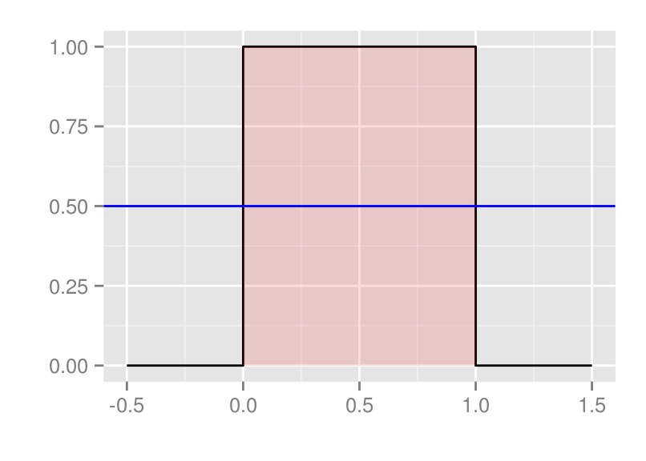

**Answer:** The median is $0.50$

# Question 3

> You are playing a game with a friend where you flip a coin and if it comes up heads you give her $X$ dollars and if it comes up tails she gives you $Y$ dollars. The odds that the coin is heads is $d$. What are your expected earnings?
1. $-X{d \over 1+d} + Y{1 \over 1+d}$
2. $X{d \over 1+d} + Y{1 \over 1+d}$
3. $X{d \over 1+d} - Y{1 \over 1+d}$
4. $-X{d \over 1+d} - Y{1 \over 1+d}$

[Watch video solution](https://www.youtube.com/watch?v=5J88Zq0q81o&list=PLpl-gQkQivXhHOcVeU3bSJg78zaDYbP9L&index=3)

## Solution

- odds of heads = $d$
- heads means $-X$ dollars
- tails means $+Y$ dollars

| Win | I win ($p$) | You win ($1-p$) |
| --- | --- | --- |
| $P(w)$ | $p$ | $1-p$ |

Over time, I expect $[Earnings] = Y(1-p) - Xp$

**Odds $(d)$ are defined as** $Odds = {p \over 1-p} \therefore p = {d \over 1 + d}$

Substitute for $p$:

$[Earnings] = Y(1 - {d \over 1 + d} - X{d \over 1 + d})$

$[Earnings] = Y({1+d - d} \over 1+d) - X{d \over 1 + d})$

**Answer:** $[Earnings] = Y(1 \over 1+d) - X{d \over 1 + d})$

# Question 4

> A random variable takes the value -4 with probability .2 and 1 with probability .8. What is the variance of this random variable?
1. 0
2. 4
3. 8
4. 16

[Watch video solution](https://www.youtube.com/watch?v=Em-xJeQO1rc&index=4&list=PLpl-gQkQivXhHOcVeU3bSJg78zaDYbP9L)

## Solution

The variance is defined in terms of expectated values: $Var(X) = E[X^2] - E[X]^2$

The expected value is the sum of possible values and their probabilities:

| $x$ | $p(x)$ | $x^2$ | $p(x^2)$ |
| --- | --- | --- | --- |
| -4 | 0.2 | 16 | 0.2 |
| 1 | 0.8 | 1 | 0.8 |

$E[X] = -4 * 0.2 + 1 * 0.8 = 0 \therefore E[X]^2 =0$

$E[X^2] = 16 * 0.2 + 1 * 0.8 = 4.0$

$\sigma^2 = E[X^2] - E[X]^2 = 4.0 - 0 = 4$

```r
# var = E[X^2] - E[X]^2
16 * .2 + 1 * .8 - (-4*.2 +1*.8)
```

```
## [1] 4
```

**Answer:** Variance = 4